# Chapter 17 Analysis of Factor Level Means

Bryan Goodrich

2015-08-08

# Chapter 17 – Analysis of Factor Level Means

## Load the data sets

```r
data("CH16TA01", package = "ALSM")
data("CH17TA02", package = "ALSM")
data("CH17TA04", package = "ALSM")
```

## TABLE 17.1

#### Summary of Results–Kenton Food Company Example

Ignored due to lack of pedagogical benefit. See Chapter 16 for details.

## Input Rust Inhibitor Data

```r
.data <- CH17TA02
names(.data) <- c("y", "x1", "x2")
fit <- lm(y ~ factor(x1), .data)
```

## TABLE 17.2 (p 735)

#### Data and Analysis of Variance Results–Rust Inhibitor Example

The last two steps demonstrate how to use the information to extract some specific values, but of course this information is already displayed in the ANOVA table, as the p-value tells us the result of the hypothesis of the F-test.

```r
addmargins(xtabs(y ~ x2 + x1, .data), 1, mean)
```

```
##       x1
## x2         1     2     3     4
##   1    43.90 89.80 68.40 36.20
##   2    39.00 87.10 69.30 45.20
##   3    46.70 92.70 68.50 40.70
##   4    43.80 90.60 66.40 40.50
##   5    44.20 87.70 70.00 39.30
##   6    47.70 92.40 68.10 40.30
##   7    43.60 86.10 70.60 43.20
##   8    38.90 88.10 65.20 38.70
##   9    43.60 90.80 63.80 40.90
##   10   40.00 89.10 69.20 39.70
##   mean 43.14 89.44 67.95 40.47
```

```r
cat("Ybar.. = ", mean(.data$y))
```

```
## Ybar.. =  60.25
```

```r
anova(fit)
```

```
## Analysis of Variance Table
##
## Response: y
##            Df Sum Sq Mean Sq F value Pr(>F)
## factor(x1)  3  15953    5318     866 <2e-16 ***
## Residuals  36    221       6
## ---
## Signif. codes:  0 '***' 0.001 '**' 0.01 '*' 0.05 '.' 0.1 ' ' 1
```

```r
anova(fit)[1, 3] / anova(fit)[2,3]  # F* = MSTR / MSE = 866.12
```

```
## [1] 866.1
```

```r
qf(0.95, 3, 36)                     # F(0.95, 3, 36) = 2.87 < F*
```

```
## [1] 2.866
```

## Input Kenton Food Company Data

```r
.data <- CH16TA01
names(.data) <- c("y", "x1", "x2")
```

## FIGURE 17.1 (p 736)

#### Line Plot of Estimated Factor Level Means–Kenton Food Company Example

I don’t know of a line plot function, but a makeshift way to generate a similar graph is to use `stripchart` (*graphics*).

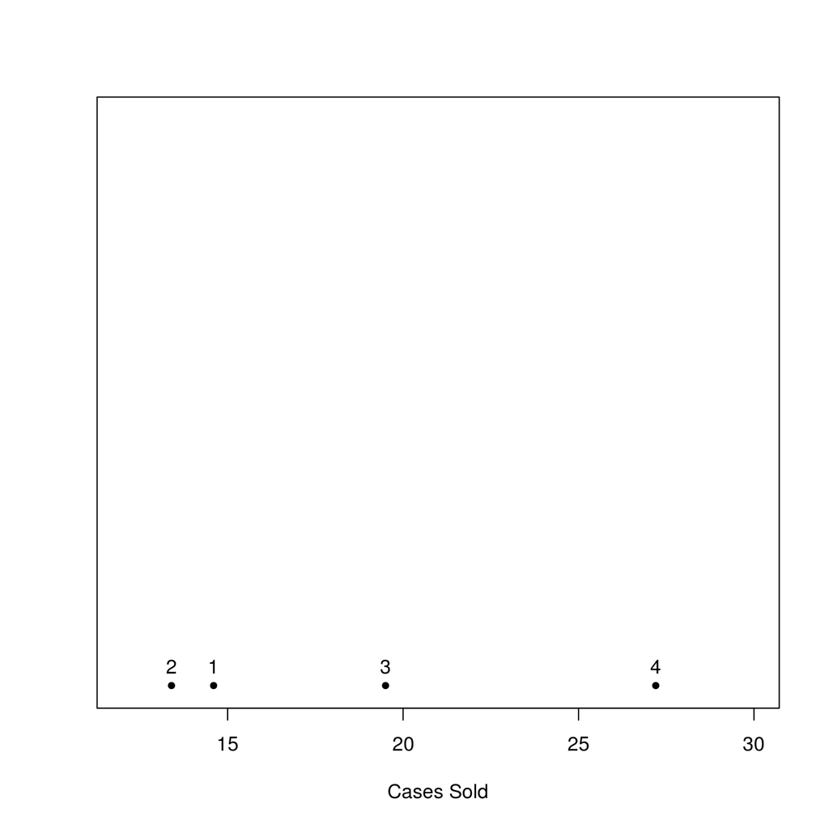

```r
with(.data, stripchart(tapply(y, x1, mean), pch = 20, ylim = c(1, 2), xlim = c(12, 30), xlab = "Cases Sold"))
with(.data, text(tapply(y, x1, mean), rep(1, 4), labels = seq(4), pos = 3))
```

## FIGURE 17.2 and FIGURE 17.3 (p 736, 739)

#### Bar Graph and Main Effects Plot of Estimated Factor Level Means–Kenton Food Company Example

#### Bar-Interval Graph and Interval Plot–Kenton Food Company Example

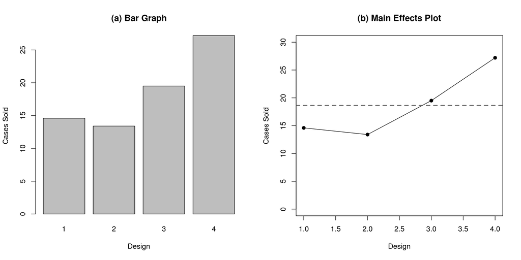

```r
# The factor means to be plotted
means <- with(.data, tapply(y, x1, mean))

# The radius portion of the 95% confidence interval for each factor
diff  <- with(.data, qt(0.975, 15) * sqrt(10.55 / tapply(y, x1, length)))

par(mfrow = c(1, 2))
barplot(means, xlab = "Design", ylab = "Cases Sold")
title("(a) Bar Graph")

plot(means, type = "o", pch = 19, ylim = c(0, 30), xlab = "Design", ylab = "Cases Sold")
abline(h = mean(.data$y), lty = 2, col = "gray40", lwd = 2)
title(main = "(b) Main Effects Plot")
```

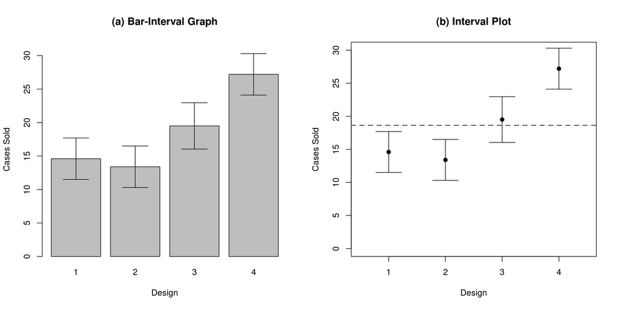

```r
bar <- barplot(means, xlab = "Design", ylab = "Cases Sold", ylim = c(0, 32))
arrows(bar, means+diff, bar, means-diff, angle = 90, code = 3)
title("(a) Bar-Interval Graph")

plot(means, pch = 19, ylim = c(0, 30), xlim = c(.5, 4.5), xlab = "Design", ylab = "Cases Sold")
arrows(seq(4), means+diff, seq(4), means-diff, angle = 90, code = 3)
abline(h = mean(.data$y), lty = 2, col = "gray40", lwd = 2)
title("(b) Interval Plot")
```

## EXAMPLE (p 739-41)

#### Inferences For Difference Between Two Factor Level Means

```r
means <- with(.data, tapply(y, x1, mean))         # Defined from earlier
D = means['3'] - means['4']                    # (17.11)
se = sqrt(10.55 * (1/4 + 1/5))                 # (17.14)
c("lwr" = D, "upr" = D) +                      # (17.16) +/- "t(0.975, 15) x se"
  c(-qt(0.975,15) * se, qt(0.975, 15) * se)
```

```
##   lwr.3   upr.3
## -12.344  -3.056
```

```r
cat('t* =', D / se)                            # (17.18)
```

```
## t* = -3.534
```

## EXAMPLE (p 741-43)

#### Inferences For Contrast of Factor Level Means

```r
lengths <- with(.data, tapply(y, x1, length))
means   <- with(.data, tapply(y, x1, mean))
cont    <- c(1/2, 1/2, -1/2, -1/2)              # contrasts
L  <- sum(cont * means)                         # (17.20)
se <- sqrt(10.55 * sum(cont^2 / lengths))       # (17.22)
c('lwr' = L, 'upr' = L) +                       # (17.24)
  c(-qt(.975, 15)*se, qt(.975, 15)*se)
```

```
##     lwr     upr
## -12.541  -6.159
```

```r
cat('t* =', L / se)                             # (17.26)
```

```
## t* = -6.245
```

## Input Rust Inhibitor Data

```r
.data <- CH17TA02
names(.data) <- c("y", "x1", "x2")
```

## FIGURE 17.4 and TABLE 17.3 (p 748-9)

#### Simultaneous Confidence Intervals and Tests for Pairwise Differences Using the Tukey Procedure–Rust Inhibitor Example

#### Paired Comparison Plot–Rust Inhibitor Example

The `TukeyHSD` method (*stats*) performs a test for pairwise differences and contains a method for plotting those differences. It is not the same as this figure, but it is just as informative. Note that `TukeyHSD` requires an `aov` object. It will not take an `lm` object.

Here `TukeyHSD` presents the appropriate p-values. If you want to test on the *q** distribution, you can look into `qtukey`. Moreover, note the differences presented. The order matters (for directionality), but the comparisons result in the same conclusions.

This same approach can be used for “Example 2–Unequal Sample Sizes” (p 750). Assuming the Kenton Food data were loaded, the following should suffice. It will be presented in the Scheffe example below.

> `TukeyHSD(aov(y ~ factor(x1), .data), conf.level = .90)`

```r
fit <- aov(y ~ factor(x1), .data)
TukeyHSD(fit)
```

```
##   Tukey multiple comparisons of means
##     95% family-wise confidence level
##
## Fit: aov(formula = y ~ factor(x1), data = .data)
##
## $`factor(x1)`
##       diff     lwr      upr  p adj
## 2-1  46.30  43.316  49.2845 0.0000
## 3-1  24.81  21.826  27.7945 0.0000
## 4-1  -2.67  -5.654   0.3145 0.0933
## 3-2 -21.49 -24.474 -18.5055 0.0000
## 4-2 -48.97 -51.954 -45.9855 0.0000
## 4-3 -27.48 -30.464 -24.4955 0.0000
```

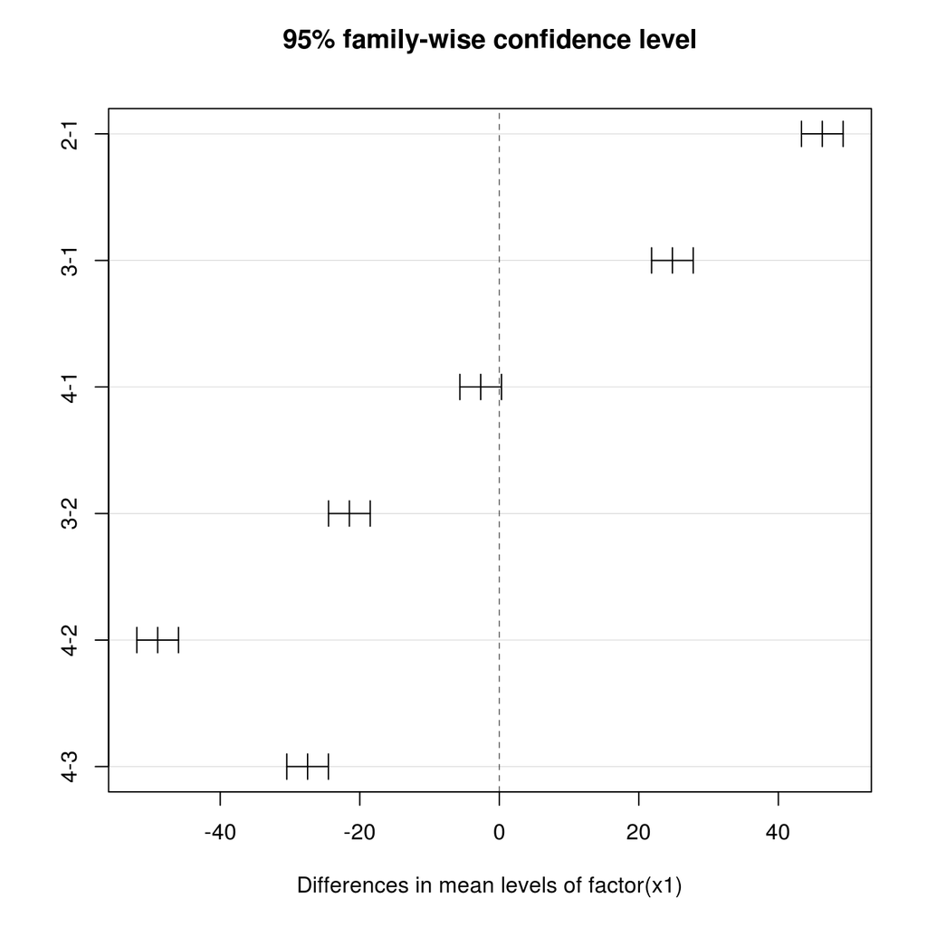

```r
plot(TukeyHSD(fit))  # Diff 4-1 contains 0
```

## Input Kenton Food Data

```r
.data <- CH16TA01
names(.data) <- c("y", "x1", "x2")
```

## EXAMPLE (p 753-5)

### Scheffe Multiple Comparison Procedure

As far as we know, R has no methods for this multiple comparison procedure. Therefore, we’ve created a function that takes a contrasts matrix

```r
Scheffe <- function(formula, data, cont, conf.level = 0.90, MSE)
{
    f  <- function(contrast, mean)   {contrast %*% mean}                # (17.41)
    h  <- function(contrast, n, MSE) {sqrt(MSE * sum(contrast^2 / n))}  # (17.42)

    .data <- model.frame(formula, data)
    y  <- .data[, 1]
    x  <- .data[, 2]
    r  <- nrow(cont)

    means <- tapply(y, x, mean)
    L     <- apply(cont, 2, f, mean = means)
    se    <- apply(cont, 2, h, n = tapply(y, x, length), MSE = MSE)
    S     <- sqrt((r-1) * qf(conf.level, r-1, nrow(.data)-r))               # (17.43a)
    L + S*cbind('lwr' = -se, 'upr' = se)                                 # (17.43)
}
cont <- matrix(c(0.5,  0.5, -0.5, -0.5,
                 0.5, -0.5,  0.5, -0.5,
                   1,   -1,    0,    0,
                   0,    0,    1,   -1), nrow = 4)
Scheffe(y ~ x1, .data, cont = cont, conf.level = 0.90, MSE = 10.55)
```

```
##          lwr     upr
## [1,] -13.442 -5.2579
## [2,]  -7.342  0.8421
## [3,]  -4.414  6.8143
## [4,] -13.655 -1.7451
```

```r
TukeyHSD(aov(y ~ factor(x1), .data), conf.level = 0.90)                 # For Example 2--Unequal Sample Sizes (p 750)
```

```
##   Tukey multiple comparisons of means
##     90% family-wise confidence level
##
## Fit: aov(formula = y ~ factor(x1), data = .data)
##
## $`factor(x1)`
##     diff    lwr    upr  p adj
## 2-1 -1.2 -6.341  3.941 0.9353
## 3-1  4.9 -0.553 10.353 0.1549
## 4-1 12.6  7.459 17.741 0.0001
## 3-2  6.1  0.647 11.553 0.0583
## 4-2 13.8  8.659 18.941 0.0000
## 4-3  7.7  2.247 13.153 0.0142
```

## EXAMPLE (p 756-7)

#### Bonferroni Multiple Comparison Procedure

```r
Bonferroni <- function(formula, data, cont, conf.level = 0.975, MSE) {
    f  <- function(contrast, mean)   {contrast %*% mean}                # (17.41)
    h  <- function(contrast, n, MSE) {sqrt(MSE * sum(contrast^2 / n))}  # (17.42)

    .data <- model.frame(formula, data)
    y  <- .data[, 1]
    x  <- .data[, 2]
    r  <- nrow(cont)
    g  <- ncol(cont)

    means <- tapply(y, x, mean)
    L     <- apply(cont, 2, f, mean = means)
    se    <- apply(cont, 2, h, n = tapply(y, x, length), MSE = MSE)
    B     <- qt(1 - (1 - conf.level)/(2*g), nrow(.data)-r)                  # (17.46a)
    L + B*cbind('lwr' = -se, 'upr' = se)                                 # (17.46)
}

# Define contrast matrix
Bonferroni(y ~ x1, .data, cont[, 1:2], conf.level = 0.975, MSE = 10.55)
```

```
##          lwr     upr
## [1,] -13.597 -5.1027
## [2,]  -7.497  0.9973
```

```r
Scheffe(y ~ x1, .data, cont = cont[, 1:2], conf.level = 0.90, MSE = 10.55)  # Compare with Scheffe
```

```
##          lwr     upr
## [1,] -13.442 -5.2579
## [2,]  -7.342  0.8421
```

```r
Bonferroni(y ~ x1, .data, cont, conf.level = 0.975, MSE = 10.55)  # Compare to Scheffe example above
```

```
##          lwr     upr
## [1,] -14.107 -4.5930
## [2,]  -8.007  1.5070
## [3,]  -5.327  7.7266
## [4,] -14.623 -0.7775
```

```r
Scheffe(y ~ x1, .data, cont = cont, conf.level = 0.90, MSE = 10.55)  # From previous example
```

```
##          lwr     upr
## [1,] -13.442 -5.2579
## [2,]  -7.342  0.8421
## [3,]  -4.414  6.8143
## [4,] -13.655 -1.7451
```

## FIGURE 17.5 (p 759)

#### Analysis of Means Plot–Kenton Food Company Example

We cannot find any ANOM methods in R, but since the computations are straightforward, both the values of interest and graphic could be designed from the following code.

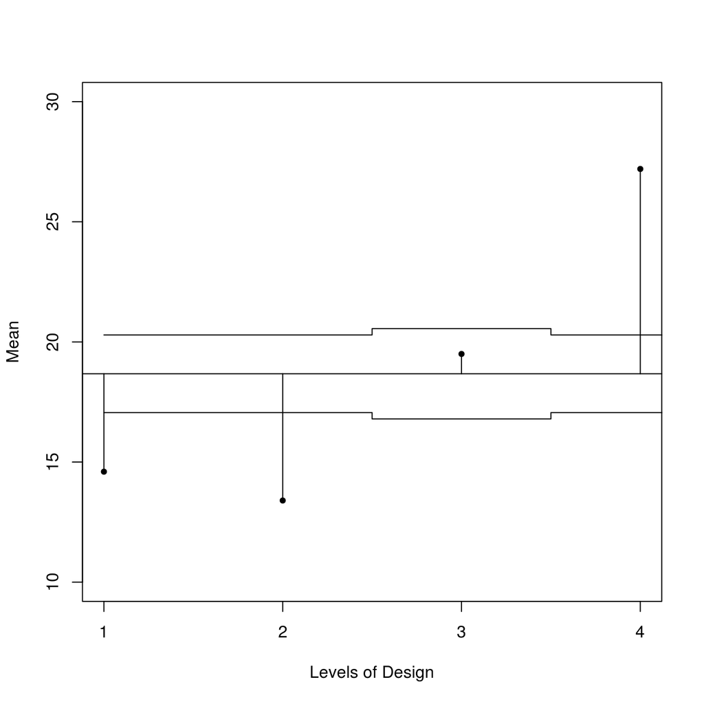

```r
r = 4
u = sum(means) / r                          # (17.48a)
n = with(.data, tapply(y, x1, length))         # lengths ni
s = vector("numeric", r)
for(i in seq(r))
  s[i] = (10.55/n[i]) * ((r-1)/r)^2 + (10.55/r^2) * sum(1/n[-i])  # (17.49)

plot(x = seq(r), means, pch = 20, ylim = c(10, 30), xlab = "Levels of Design", ylab = "Mean", xaxt = 'n')
axis(1, seq(4))
segments(seq(4), u, seq(4), means)
lines(seq(1, 4.5, 0.5), rep(u+s, each = 2), type = "S")
lines(seq(1, 4.5, 0.5), rep(u-s, each = 2), type = "S")
abline(h = u)
```

## Input Piecework Trainees Data

```r
.data <- CH17TA04
names(.data) <- c("Y", "X1", "X2")
.data <- transform(.data, X1 = factor(X1, labels = c(' 6 hours', ' 8 hours', '10 hours', '12 hours')))
```

## TABLE 17.4 and FIGURE 17.6 (p 762-3)

#### Data–Piecework Trainees Example

#### Computer Output–Piecework Trainees Example

To get homogeneous subsets, one could use `multcompTs` (*multcompView*), and feed it the respective p-value matrix from `TukeyHSD`. This results in a matrix of {-1, 0, 1} values, where -1 indicates they are significantly different, 1 is the base (comparing a level to itself), and 0 is no significant difference. This may be more useful in locating those differences in large number of cases. However, since it is entirely based on the p-values of `TukeyHSD`, one could also (1) extract the non-significant p-values or plot them to maybe visually inspect those that include 0 in their confidence intervals.

```r
fit <- aov(Y ~ X1, .data)
addmargins(xtabs(Y ~ X1 + X2, .data, sparse = TRUE), 2, list(list('Mean' = mean, 'SD' = sd)))
```

```
##           1  2  3  4  5  6  7  Mean    SD
##  6 hours 40 39 39 36 42 43 41 40.00 2.309
##  8 hours 53 48 49 50 51 50 48 49.86 1.773
## 10 hours 53 58 56 59 53 59 58 56.57 2.637
## 12 hours 63 62 59 61 62 62 61 61.43 1.272
```

```r
model.tables(fit, "means")                      # Alternative way to see table of means
```

```
## Tables of means
## Grand mean
##
## 51.96
##
##  X1
## X1
##  6 hours  8 hours 10 hours 12 hours
##    40.00    49.86    56.57    61.43
```

```r
summary(fit)                                    # ANOVA summary
```

```
##             Df Sum Sq Mean Sq F value  Pr(>F)
## X1           3   1809     603     141 2.2e-15 ***
## Residuals   24    102       4
## ---
## Signif. codes:  0 '***' 0.001 '**' 0.01 '*' 0.05 '.' 0.1 ' ' 1
```

```r
summary.lm(fit)                                 # Coefficients are mean difference from "6 hours" mean
```

```
##
## Call:
## aov(formula = Y ~ X1, data = .data)
##
## Residuals:
##    Min     1Q Median     3Q    Max
## -4.000 -1.000  0.143  1.429  3.143
##
## Coefficients:
##             Estimate Std. Error t value Pr(>|t|)
## (Intercept)    40.00       0.78   51.26  < 2e-16 ***
## X1 8 hours      9.86       1.10    8.93  4.2e-09 ***
## X110 hours     16.57       1.10   15.02  1.1e-13 ***
## X112 hours     21.43       1.10   19.42  3.5e-16 ***
## ---
## Signif. codes:  0 '***' 0.001 '**' 0.01 '*' 0.05 '.' 0.1 ' ' 1
##
## Residual standard error: 2.06 on 24 degrees of freedom
## Multiple R-squared:  0.946,  Adjusted R-squared:  0.94
## F-statistic:  141 on 3 and 24 DF,  p-value: 2.17e-15
```

```r
TukeyHSD(fit)                                   # 1st 3 'diff' match lm model coefficients
```

```
##   Tukey multiple comparisons of means
##     95% family-wise confidence level
##
## Fit: aov(formula = Y ~ X1, data = .data)
##
## $X1
##                     diff    lwr    upr p adj
##  8 hours- 6 hours  9.857  6.813 12.901 0.000
## 10 hours- 6 hours 16.571 13.527 19.616 0.000
## 12 hours- 6 hours 21.429 18.384 24.473 0.000
## 10 hours- 8 hours  6.714  3.670  9.758 0.000
## 12 hours- 8 hours 11.571  8.527 14.616 0.000
## 12 hours-10 hours  4.857  1.813  7.901 0.001
```

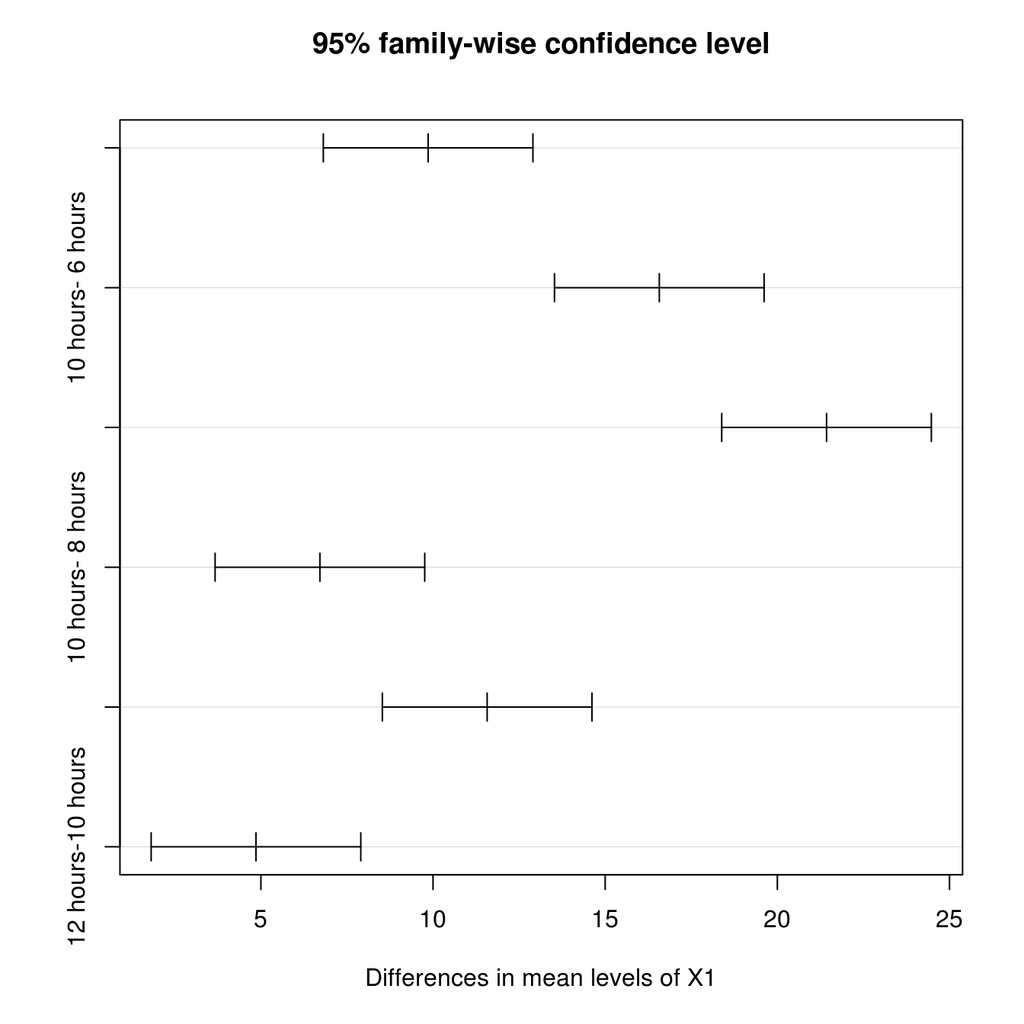

```r
plot(TukeyHSD(fit))
```

```r
cat("q* =", qtukey(0.95, 4, 24))
```

```
## q* = 3.901
```

```r
diff(with(.data, tapply(Y, X1, mean)))             # Diminishing returns to training (p 764)
```

```
##  8 hours 10 hours 12 hours
##    9.857    6.714    4.857
```

## FIGURE 17.7 and TABLE 17.5 (p 764-5)

#### Scatter plot and Fitted Quadratic Response Function–Piecework Trainees Example

#### Illustration of Data for Regression Analysis–Piecework Trainees Example

Since we’re treating `X1` as a factor, we manually specify it as a vector below. The mean can been taken as this vector mean (`= 9`).

```r
x1 <- rep(seq(6, 12, 2), each = 7)                  # numeric encoding of X1
xx <- seq(min(x1), max(x1), len = 200)              # For curve plotting below
.data <- transform(.data, x = c(scale(x1, TRUE, FALSE)))  # Center X1
.data <- transform(.data, X = x1)                         # Store the numeric encoding
(.data <- transform(.data, xsq = x*x))                    # TABLE 17.5
```

```
##     Y       X1 X2  x  X xsq
## 1  40  6 hours  1 -3  6   9
## 2  39  6 hours  2 -3  6   9
## 3  39  6 hours  3 -3  6   9
## 4  36  6 hours  4 -3  6   9
## 5  42  6 hours  5 -3  6   9
## 6  43  6 hours  6 -3  6   9
## 7  41  6 hours  7 -3  6   9
## 8  53  8 hours  1 -1  8   1
## 9  48  8 hours  2 -1  8   1
## 10 49  8 hours  3 -1  8   1
## 11 50  8 hours  4 -1  8   1
## 12 51  8 hours  5 -1  8   1
## 13 50  8 hours  6 -1  8   1
## 14 48  8 hours  7 -1  8   1
## 15 53 10 hours  1  1 10   1
## 16 58 10 hours  2  1 10   1
## 17 56 10 hours  3  1 10   1
## 18 59 10 hours  4  1 10   1
## 19 53 10 hours  5  1 10   1
## 20 59 10 hours  6  1 10   1
## 21 58 10 hours  7  1 10   1
## 22 63 12 hours  1  3 12   9
## 23 62 12 hours  2  3 12   9
## 24 59 12 hours  3  3 12   9
## 25 61 12 hours  4  3 12   9
## 26 62 12 hours  5  3 12   9
## 27 62 12 hours  6  3 12   9
## 28 61 12 hours  7  3 12   9
```

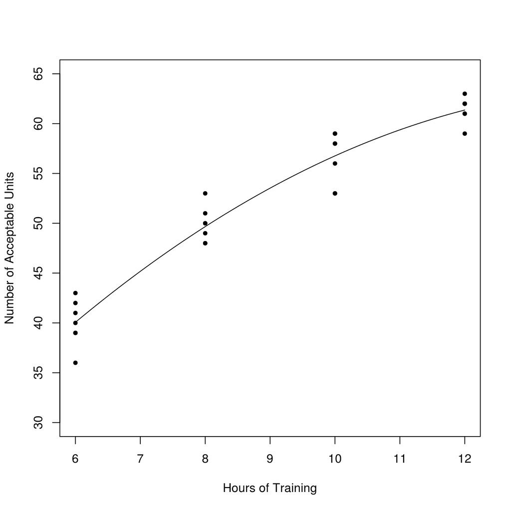

```r
plot(.data$Y ~ x1, pch = 20, ylim = c(30, 65), xlab = "Hours of Training", ylab = "Number of Acceptable Units")
lines(xx, coef(lm(Y ~ X + I(X^2), .data)) %*% rbind(1, xx, xx^2))  # Uses (17.51)
```

## TABLE 17.6 (p 765)

#### Analysis of Variance–Piecework Trainees Example

Recall that R `anova` will output a breakdown of the Regression SS. Simply aggregating the components appropriately produces the book results.

`1764.35 + 43.75 = 1808.1`

Divide that by the degrees of freedom (2) will match the Regression MS.

```r
fit <- lm(Y ~ x + xsq, .data)  # (17.52)

anova(fit)                  # (a) Regression Model (17.51)
```

```
## Analysis of Variance Table
##
## Response: Y
##           Df Sum Sq Mean Sq F value Pr(>F)
## x          1   1764    1764   428.8 <2e-16 ***
## xsq        1     44      44    10.6 0.0032 **
## Residuals 25    103       4
## ---
## Signif. codes:  0 '***' 0.001 '**' 0.01 '*' 0.05 '.' 0.1 ' ' 1
```

```r
anova(lm(Y ~ X1, .data))       # (b) ANOVA (17.50)
```

```
## Analysis of Variance Table
##
## Response: Y
##           Df Sum Sq Mean Sq F value  Pr(>F)
## X1         3   1809     603     141 2.2e-15 ***
## Residuals 24    102       4
## ---
## Signif. codes:  0 '***' 0.001 '**' 0.01 '*' 0.05 '.' 0.1 ' ' 1
```

```r
anova(fit, lm(Y ~ X1, .data))  # (c) ANOVA for Lack of Fit
```

```
## Analysis of Variance Table
##
## Model 1: Y ~ x + xsq
## Model 2: Y ~ X1
##   Res.Df RSS Df Sum of Sq    F Pr(>F)
## 1     25 103
## 2     24 102  1     0.579 0.14   0.72
```